# HW10_solution

```python
#載入所需函示庫

#載入所需函示庫
from matplotlib import pyplot as plt
%matplotlib inline
# 設定圖形大小; DPI越大圖越大
plt.rcParams["figure.dpi"] = 60
import seaborn as sns
import pandas as pd
import numpy as np
import scipy.stats as stats
import statsmodels.api as sm
import statsmodels.stats.api as sms
import statsmodels.formula.api as smf
import statsmodels.stats.multicomp as smm
import statsmodels.stats.outliers_influence as sso
import statsmodels
import statistics
import math
```

```python
def CI_PI_regression(xdata, yval, x1, a):
    print("make CI and PI prediction at mean of x = ", x1)
    X_data_T = xdata.T
    X_data2 = sm.add_constant(X_data_T)
    olsmod = sm.OLS(yval, X_data2)
    result_reg = olsmod.fit()
    y_head = np.dot(result_reg.params, x1)
    print("y_head = ", y_head)
    (t_minus, t_plus) = stats.t.interval(alpha = (1.0 - a), df = result_reg.df_resid )
    core1 = (result_reg.mse_resid * np.matmul(x1, np.linalg.solve(np.matmul(X_data2.T, X_data2), x1))) ** 0.5
    lower_bound = y_head +  t_minus * core1
    upper_bound = y_head +  t_plus * core1
    print("confidence interval of mean = [%0.4f, %0.4f] " % (lower_bound, upper_bound))
    core2 = (result_reg.mse_resid * (1 + np.matmul(x1, np.linalg.solve(np.matmul(X_data2.T, X_data2), x1)))) ** 0.5
    lower_bound2 = y_head +  t_minus * core2
    upper_bound2 = y_head +  t_plus * core2
    print("Prediction interval = [%0.4f, %0.4f] " % (lower_bound2, upper_bound2))
    CI_PI = np.array([lower_bound, upper_bound, lower_bound2, upper_bound2])
    return CI_PI
```

```python
def runsTest(l, l_median):
    runs, n1, n2 = 1, 0, 0
    if(l[0]) >= l_median:
        n1 += 1
    else:
        n2 += 1
    for i in range(1, len(l)):
        if (l[i] >= l_median and l[i-1] < l_median) or (l[i] < l_median and l[i-1] >= l_median):
            runs += 1
        if(l[i]) >= l_median:
            n1 += 1
        else:
            n2 += 1
    runs_exp = ((2*n1*n2)/(n1+n2)) + 1
    stan_dev = math.sqrt((2*n1*n2*(2*n1*n2-n1-n2))/(((n1+n2)**2)*(n1+n2-1)))
    z = (runs-runs_exp)/stan_dev
    pval_z = stats.norm.sf(abs(z)) * 2
    print('runs = ', runs)
    print('n1 = ', n1)
    print('n2 = ', n2)
    print('runs_exp = ', runs_exp)
    print('stan_dev = ', stan_dev)
    print('z = ', z)
    print('pval_z = ', pval_z)
    return pval_z
```

## 17.3

X(independent variable) - Permits(x1), Mortgage(x2)(%), A Vacancy(x3)(%), O Vacancy(x4)(%)  
y(dependent variable) - Drywall monthly sales(in hundreds of 4x8 sheets)

```python
#讀取資料集
df = pd.read_excel('Xr17-03.xlsx')
print('Dataset(head):')
display(df.head())
print('Dataset(tail):')
display(df.tail())
```

```
Dataset(head):
```

|  | Drywall | Permits | Mortgage | A Vacancy | O Vacancy |
| --- | --- | --- | --- | --- | --- |
| 0 | 328 | 49 | 8.35 | 2.98 | 13.43 |
| 1 | 376 | 79 | 8.08 | 5.60 | 14.51 |
| 2 | 373 | 79 | 7.90 | 2.25 | 14.24 |
| 3 | 144 | 50 | 7.69 | 4.26 | 14.30 |
| 4 | 194 | 37 | 7.00 | 2.60 | 11.64 |

```
Dataset(tail):
```

|  | Drywall | Permits | Mortgage | A Vacancy | O Vacancy |
| --- | --- | --- | --- | --- | --- |
| 19 | 280 | 49 | 7.57 | 3.25 | 19.94 |
| 20 | 101 | 14 | 8.44 | 3.61 | 15.47 |
| 21 | 297 | 66 | 8.43 | 2.13 | 12.75 |
| 22 | 309 | 62 | 8.14 | 4.35 | 12.24 |
| 23 | 233 | 40 | 8.81 | 2.31 | 18.65 |

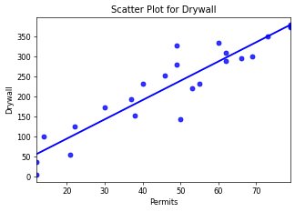

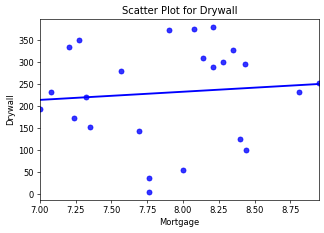

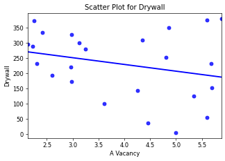

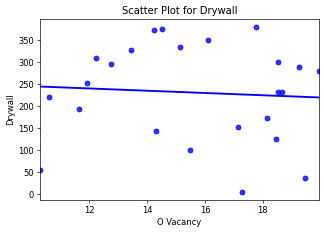

```python
y_var = df['Drywall'].values
xnames = ['Permits', 'Mortgage', 'A Vacancy', 'O Vacancy']
for aname in xnames:
    x_var = df[aname].values
    _ = sns.regplot(x = x_var, y = y_var, data = df, color = 'b', ci = None)
    plt.title('Scatter Plot for Drywall')
    plt.xlabel(aname)
    plt.ylabel('Drywall')
    plt.show()
```

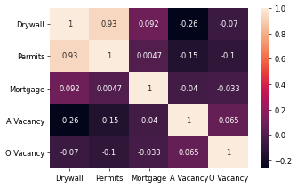

```python
corr = df.corr()
_ = sns.heatmap(corr, annot=True)
```

Sales = $\beta 0 $ + $\beta 1 $ x1 + $\beta 2 $ x2 + $\beta 3 $ x3 + $\beta 4 $ x4 + $\epsilon$

```python
y = df['Drywall']

X_ar = np.array([df['Permits'], df['Mortgage'], df['A Vacancy'], df['O Vacancy']])
X_T =X_ar.T
X = pd.DataFrame(X_T,columns = xnames)
X = sm.add_constant(X)

olsmod = sm.OLS(y, X)
result = olsmod.fit()
print(result.summary())
```

```
                            OLS Regression Results
==============================================================================
Dep. Variable:                Drywall   R-squared:                       0.894
Model:                            OLS   Adj. R-squared:                  0.871
Method:                 Least Squares   F-statistic:                     39.86
Date:                Mon, 31 May 2021   Prob (F-statistic):           5.45e-09
Time:                        01:31:50   Log-Likelihood:                -119.86
No. Observations:                  24   AIC:                             249.7
Df Residuals:                      19   BIC:                             255.6
Df Model:                           4
Covariance Type:            nonrobust
==============================================================================
                 coef    std err          t      P>|t|      [0.025      0.975]
------------------------------------------------------------------------------
const       -111.8276    134.343     -0.832      0.416    -393.010     169.355
Permits        4.7631      0.395     12.057      0.000       3.936       5.590
Mortgage      16.9885     15.159      1.121      0.276     -14.739      48.716
A Vacancy    -10.5278      6.394     -1.646      0.116     -23.911       2.856
O Vacancy      1.3079      2.791      0.469      0.645      -4.533       7.149
==============================================================================
Omnibus:                        0.738   Durbin-Watson:                   1.755
Prob(Omnibus):                  0.691   Jarque-Bera (JB):                0.291
Skew:                          -0.270   Prob(JB):                        0.865
Kurtosis:                       3.006   Cond. No.                         909.
==============================================================================

Notes:
[1] Standard Errors assume that the covariance matrix of the errors is correctly specified.
```

```python
print("Estimated model: y = %0.4f" % (result.params[0]), end = ' ')
for c, x in zip(result.params[1:], list(range(1,5))):
    print('+', end = '') if c> 0 else print('-', end = '')
    print(" %0.4f x%d " % (abs(c), x), end = '')
```

```
Estimated model: y = -111.8276 + 4.7631 x1 + 16.9885 x2 - 10.5278 x3 + 1.3079 x4
```

#### (b)

```python
print('Standard errors:', result.mse_resid ** 0.5)
print('Y_bar:', df["Drywall"].mean())
```

```
Standard errors: 40.132385042777365
Y_bar: 230.95833333333334
```

It is an estimate of the standard deviation of the error variable.  
Compared to y_bar = 230.958, Se = 40.132 is relatively small. Hence our regression model of is good.

#### (c)

```python
print("R2:", result.rsquared)
print("adjusted R2:", result.rsquared_adj)
```

```
R2: 0.8935208939200665
adjusted R2: 0.8711042400085016
```

89.35% of the variation in monthly sales of drywall is explained by the model.  
| R2 - adjusted R2 | < 0.06, which indicates model doesn't have problem of over-fitting.

#### (d)

H0 : $\beta i $ = 0 for i in [1,4]  
H1 : exists at least one $\beta i$ != 0 for i in [1,4]  
$\alpha$ = 0.05

```python
print("F-statistics:", result.fvalue)
print("p-value:",result.f_pvalue)
```

```
F-statistics: 39.85969081045996
p-value: 5.447622071673194e-09
```

Since p-value < alpha = 0.05, we reject H0 at significance level at alpha = 0.05.  
There is enough evidence to conclude that the model is valid.

#### (e)

b1 = 4.76; for each addition building permit monthly sales on average increase by 4.76 hundred sheets provided that the other variables remain constant.  
b2 = 16.99; for each addition one point increase in mortgage rates monthly sales on average increase by 16.99 hundred sheets provided that the other variables remain constant.  
b3 = –10.53; for each one percentage point increase in the apartment vacancy rate monthly sales decrease on average by 10.53 hundred sheets provided that the other variables remain constant.  
b4 = 1.31; for each one percentage point increase in the office vacancy rate monthly sales increase on average by 1.31 hundred sheets provided that the other variables remain constant.

#### (f)

H0 : $\beta i$ = 0 for i in [1,4]  
H1 : $\beta i$ != 0 for i in [1,4]  
$\alpha$ = 0.05

```python
for x, p in zip(xnames, result.pvalues[1:]):
    print("p-value of %s = %0.3f" % (x, p))
    if p < 0.05:
        print("  Since p-value < alpha = 0.05, we reject H0 at significance level at alpha = 0.05.")
        print("  There is enough evidence to infer that %s is linearly related to monthly sales.\n" %x)
    else:
        print("  Since p-value > alpha = 0.05, we can not reject H0 at significance level at alpha = 0.05.")
        print("  There is not enough evidence to infer that %s is linearly related to monthly sales.\n" %x)
```

```
p-value of Permits = 0.000
  Since p-value < alpha = 0.05, we reject H0 at significance level at alpha = 0.05.
  There is enough evidence to infer that Permits is linearly related to monthly sales.

p-value of Mortgage = 0.276
  Since p-value > alpha = 0.05, we can not reject H0 at significance level at alpha = 0.05.
  There is not enough evidence to infer that Mortgage is linearly related to monthly sales.

p-value of A Vacancy = 0.116
  Since p-value > alpha = 0.05, we can not reject H0 at significance level at alpha = 0.05.
  There is not enough evidence to infer that A Vacancy is linearly related to monthly sales.

p-value of O Vacancy = 0.645
  Since p-value > alpha = 0.05, we can not reject H0 at significance level at alpha = 0.05.
  There is not enough evidence to infer that O Vacancy is linearly related to monthly sales.
```

```python
xg = np.array([1, 50, 9, 3.6, 14.3])
CI_PI_result = CI_PI_regression(X_ar, y, xg, 0.05)
print(CI_PI_result)
```

```
make CI and PI prediction at mean of x =  [ 1.  50.   9.   3.6 14.3]
y_head =  260.0254241044899
confidence interval of mean = [220.3326, 299.7182]
Prediction interval = [167.1212, 352.9296]
[220.33261558 299.71823263 167.1212208  352.92962741]
```

Next month’s drywall sales are predicted to lie between 16,712 and 35,293 sheets.

### Residual analysis

```python
st, data, ss2 = sso.summary_table(result, alpha=0.05)
#Predicted value
y_pre = data[:, 2]
#Studentized Residual
SD = data[:, 10]
```

#### Normality

H0 : Normal distributed  
H1 : Not normal distributed

```python
stat, p = stats.shapiro(SD)
print('Shapiro Test: Statistics=%f, p=%f' % (stat, p))
```

```
Shapiro Test: Statistics=0.968704, p=0.635093
```

Since p-value > alpha = 0.05, we can not reject H0 at significance level at alpha = 0.05.  
There is no evidence to show that it is not normally distributed.

#### Homoscedasticity

H0 : Homoscedasticity  
H1 : Not Homoscedasticity

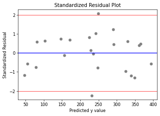

```python
plt.plot(y_pre, SD, 'o', color = 'gray')
plt.axhline(y=2, color = 'red', lw = 0.8)
plt.axhline(y=0, color = 'blue')
plt.axhline(y=-2, color = 'red', lw = 0.8)
plt.title('Standardized Residual Plot')
plt.xlabel('Predicted y value')
plt.ylabel('Standardized Residual')
plt.show()
```

We do not reject H0. We can assume the variation is constant and the mean is around 0.

#### Independence

H0 : Independence  
H1 : Not independence

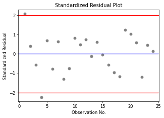

```
runs =  14
n1 =  12
n2 =  12
runs_exp =  13.0
stan_dev =  2.395648228514071
z =  0.417423554968361
pval_z =  0.6763686287244615
p_value for Z-statistic=  0.6763686287244615
```

```python
Id = data[:, 0]
plt.plot(Id, SD, 'o', color = 'gray')
plt.axhline(y=0, color = 'blue')
plt.axhline(y=2, color = 'red')
plt.axhline(y=-2, color = 'red')
plt.title('Standardized Residual Plot')
plt.xlabel('Observation No.')
plt.ylabel('Standardized Residual')
plt.show()

SD_median = statistics.median(SD)
Z_pval = runsTest(SD, SD_median)
print('p_value for Z-statistic= ', Z_pval)
```

Since n1<20 and n2<20, we check with run table.  
lower bound = 7 < runs = 14 < upper bound =19  
Thus, there is no evidence to infer the sample is not random selected.

```python
df_c = pd.DataFrame(SD,columns = ['SD'])
filter = (df_c['SD'] < -2) | (df_c['SD'] > 2)
print("Outliers by SD = \n")
print(df_c['SD'].loc[filter])
```

```
Outliers by SD =

0    2.072873
3   -2.231462
Name: SD, dtype: float64
```

```python
X = np.array(X)
H = np.matmul(X, np.linalg.solve(np.matmul(X.T, X), X.T))
df['hii'] = np.diagonal(H)
df_h = pd.DataFrame(df['hii'])
k = result.df_model
n = len(df_h['hii'])
h_level = 3 * (k+1) / n
print("h_level = ", h_level)
print(" \n")
filter = (df_h['hii'] > h_level )
print("Influential Observations by hi = \n")
print(df_h['hii'].loc[filter])
```

```
h_level =  0.625


Influential Observations by hi =

Series([], Name: hii, dtype: float64)
```

```python
s2_e = result.mse_resid
k = result.df_model
y_a = data[:, 1]
y_f = data[:, 2]
h_i = df['hii']
CD_arr = np.square(y_a - y_f) / s2_e / (k - 1) * h_i / np.square(1 - h_i)
CD = np.array(CD_arr)
df_cd = pd.DataFrame(CD,columns = ['CD'])
filter = (df_cd['CD'] > 1 )
print("Influential Observations by Cook's Distances = \n")
print(df_cd['CD'].loc[filter])
```

```
Influential Observations by Cook's Distances =

Series([], Name: CD, dtype: float64)
```

## 17.7

X(independent variable) - Direct(x1)(thousans of dollars), Newspaper(x2)(thousans of dollars), Television(x3)(thousans of dollars)  
y(dependent variable) - Sales(thousans of dollars)

```python
#讀取資料集
df = pd.read_excel('Xr17-07.xlsx')
print('Dataset(head):')
display(df.head())
print('Dataset(tail):')
display(df.tail())
```

```
Dataset(head):
```

|  | Sales | Direct | Newspaper | Television |
| --- | --- | --- | --- | --- |
| 0 | 15.98 | 1.05 | 1.35 | 1.55 |
| 1 | 21.59 | 1.29 | 2.25 | 1.97 |
| 2 | 25.47 | 0.96 | 1.79 | 1.64 |
| 3 | 16.02 | 1.51 | 1.73 | 1.73 |
| 4 | 16.58 | 1.30 | 1.71 | 1.61 |

```
Dataset(tail):
```

|  | Sales | Direct | Newspaper | Television |
| --- | --- | --- | --- | --- |
| 20 | 20.09 | 0.97 | 1.72 | 1.59 |
| 21 | 19.83 | 1.01 | 1.72 | 1.42 |
| 22 | 18.42 | 1.29 | 1.47 | 2.05 |
| 23 | 21.99 | 1.35 | 1.94 | 2.28 |
| 24 | 20.57 | 1.07 | 2.31 | 1.77 |

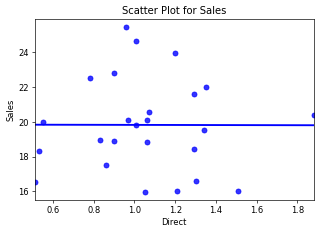

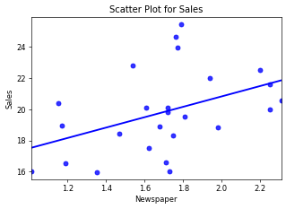

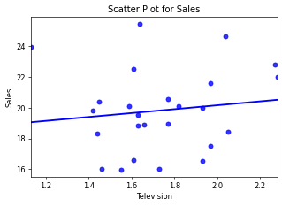

```python
y_var = df['Sales'].values
xnames = ['Direct', 'Newspaper', 'Television']
for aname in xnames:
    x_var = df[aname].values
    _ = sns.regplot(x = x_var, y = y_var, data = df, color = 'b', ci = None)
    plt.title('Scatter Plot for Sales')
    plt.xlabel(aname)
    plt.ylabel('Sales')
    plt.show()
```

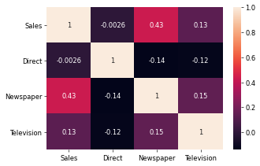

```python
corr = df.corr()
_ = sns.heatmap(corr, annot=True)
```

Sales = $\beta 0 $ + $\beta 1 $ x1 + $\beta 2 $ x2 + $\beta 3 $ x3 + $\epsilon$

```python
y = df['Sales']

X_ar = np.array([df['Direct'], df['Newspaper'], df['Television']])
X_T =X_ar.T
X = pd.DataFrame(X_T,columns = xnames)
X = sm.add_constant(X)

olsmod = sm.OLS(y, X)
result = olsmod.fit()
print(result.summary())
```

```
                            OLS Regression Results
==============================================================================
Dep. Variable:                  Sales   R-squared:                       0.195
Model:                            OLS   Adj. R-squared:                  0.080
Method:                 Least Squares   F-statistic:                     1.698
Date:                Mon, 31 May 2021   Prob (F-statistic):              0.198
Time:                        01:31:51   Log-Likelihood:                -57.058
No. Observations:                  25   AIC:                             122.1
Df Residuals:                      21   BIC:                             127.0
Df Model:                           3
Covariance Type:            nonrobust
==============================================================================
                 coef    std err          t      P>|t|      [0.025      0.975]
------------------------------------------------------------------------------
const         12.3084      4.698      2.620      0.016       2.538      22.079
Direct         0.5699      1.720      0.331      0.744      -3.008       4.147
Newspaper      3.3200      1.539      2.157      0.043       0.120       6.520
Television     0.7322      1.958      0.374      0.712      -3.341       4.805
==============================================================================
Omnibus:                        2.472   Durbin-Watson:                   1.953
Prob(Omnibus):                  0.290   Jarque-Bera (JB):                1.818
Skew:                           0.657   Prob(JB):                        0.403
Kurtosis:                       2.857   Cond. No.                         27.7
==============================================================================

Notes:
[1] Standard Errors assume that the covariance matrix of the errors is correctly specified.
```

```python
print("Estimated model: y = %0.4f" % (result.params[0]), end = ' ')
for c, x in zip(result.params[1:], list(range(1,5))):
    print('+', end = '') if c> 0 else print('-', end = '')
    print(" %0.4f x%d " % (abs(c), x), end = '')
```

```
Estimated model: y = 12.3084 + 0.5699 x1 + 3.3200 x2 + 0.7322 x3
```

#### (b)

```python
print("R2:", result.rsquared)
print("adjusted R2:", result.rsquared_adj)
```

```
R2: 0.19525348361224804
adjusted R2: 0.08028969555685495
```

The coefficient of determination is = .1953; 19.53% of the variation in sales is explained by the model.  
The coefficient of determination adjusted for degrees of freedom is .0803. The model fits poorly.  
| R2 - adjusted R2 | > 0.06, which indicates model might have problem of over-fitting.

#### (c)

```python
print('Standard errors: ', result.mse_resid ** 0.5)
print('Y_bar:', df["Sales"].mean())
```

```
Standard errors:  2.5871435824215028
Y_bar: 19.821600000000004
```

#### (d)

H0 : $\beta i $ = 0 for i in [1,3]  
H1 : exists at least one $\beta i$ != 0 for i in [1,3]  
$\alpha$ = 0.05

```python
print("F-statistics:", result.fvalue)
print("p-value:",result.f_pvalue)
```

```
F-statistics: 1.6983911796484028
p-value: 0.19792494256872106
```

Since p-value > alpha = 0.05, we can not reject H0 at significance level at alpha = 0.05.  
There is not enough evidence to conclude that the model is valid.

#### (e)

H0 : $\beta i$ = 0 for i in [1,4]  
H1 : $\beta i$ != 0 for i in [1,4]  
$\alpha$ = 0.05

```python
for x, p in zip(xnames, result.pvalues[1:]):
    print("p-value of %s = %0.3f" % (x, p))
    if p < 0.05:
        print("  Since p-value < alpha = 0.05, we reject H0 at significance level at alpha = 0.05.")
        print("  There is enough evidence to infer that %s is linearly related to monthly sales.\n" %x)
    else:
        print("  Since p-value > alpha = 0.05, we can not reject H0 at significance level at alpha = 0.05.")
        print("  There is not enough evidence to infer that %s is linearly related to monthly sales.\n" %x)
```

```
p-value of Direct = 0.744
  Since p-value > alpha = 0.05, we can not reject H0 at significance level at alpha = 0.05.
  There is not enough evidence to infer that Direct is linearly related to monthly sales.

p-value of Newspaper = 0.043
  Since p-value < alpha = 0.05, we reject H0 at significance level at alpha = 0.05.
  There is enough evidence to infer that Newspaper is linearly related to monthly sales.

p-value of Television = 0.712
  Since p-value > alpha = 0.05, we can not reject H0 at significance level at alpha = 0.05.
  There is not enough evidence to infer that Television is linearly related to monthly sales.
```

#### (f) (g) (h)

```python
xg = np.array([1, 0.8, 1.2, 2])
CI_PI_result = CI_PI_regression(X_ar, y, xg, 0.05)
print(CI_PI_result)
```

```
make CI and PI prediction at mean of x =  [1.  0.8 1.2 2. ]
y_head =  18.212662385714037
confidence interval of mean = [15.6968, 20.7285]
Prediction interval = [12.2732, 24.1521]
[15.69681447 20.7285103  12.27324455 24.15208022]
```

(f) We predict that sales will fall between $12,270 and $24,150.  
(g) We estimate that mean sales will fall between $15,700 and $20,730.  
(h) The interval in part f predicts one week’s gross sales, whereas the interval in part g estimates the mean weekly gross sales.

### Residual analysis

```python
st, data, ss2 = sso.summary_table(result, alpha=0.05)
#Predicted value
y_pre = data[:, 2]
#Studentized Residual
SD = data[:, 10]
```

#### Normality

H0 : Normal distributed  
H1 : Not normal distributed

```python
stat, p = stats.shapiro(SD)
print('Shapiro Test: Statistics=%.3f, p=%.3f' % (stat, p))
```

```
Shapiro Test: Statistics=0.942, p=0.161
```

Since p-value > alpha = 0.05, we can not reject H0 at significance level at alpha = 0.05.  
There is no evidence to show that it is not normally distributed.

#### Homoscedasticity

H0 : Homoscedasticity  
H1 : Not Homoscedasticity

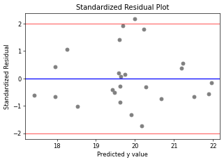

```python
plt.plot(y_pre, SD, 'o', color = 'gray')
plt.axhline(y=2, color = 'red', lw = 0.8)
plt.axhline(y=0, color = 'blue')
plt.axhline(y=-2, color = 'red', lw = 0.8)
plt.title('Standardized Residual Plot')
plt.xlabel('Predicted y value')
plt.ylabel('Standardized Residual')
plt.show()
```

We do not reject H0. We can assume the variation is constant and the mean is around 0.

#### Independence

H0 : Independence  
H1 : Not independence

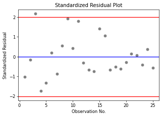

```
runs =  13
n1 =  13
n2 =  12
runs_exp =  13.48
stan_dev =  2.443276488652072
z =  -0.19645750377797438
pval_z =  0.8442520915487808
p_value for Z-statistic=  0.8442520915487808
```

```python
Id = data[:, 0]
plt.plot(Id, SD, 'o', color = 'gray')
plt.axhline(y=0, color = 'blue')
plt.axhline(y=2, color = 'red')
plt.axhline(y=-2, color = 'red')
plt.title('Standardized Residual Plot')
plt.xlabel('Observation No.')
plt.ylabel('Standardized Residual')
plt.show()

SD_median = statistics.median(SD)
Z_pval = runsTest(SD, SD_median)
print('p_value for Z-statistic= ', Z_pval)
```

Since n1<20 and n2<20, we check with run table.  
lower bound = 8 < runs = 13 < upper bound =19  
Thus, there is no evidence to infer the sample is not random selected.

```python
df_c = pd.DataFrame(SD,columns = ['SD'])
filter = (df_c['SD'] < -2) | (df_c['SD'] > 2)
print("Outliers by SD = \n")
print(df_c['SD'].loc[filter])
```

```
Outliers by SD =

2    2.173337
Name: SD, dtype: float64
```

```python
X = np.array(X)
H = np.matmul(X, np.linalg.solve(np.matmul(X.T, X), X.T))
df['hii'] = np.diagonal(H)
df_h = pd.DataFrame(df['hii'])
k = result.df_model
n = len(df_h['hii'])
h_level = 3 * (k+1) / n
print("h_level = ", h_level)
print(" \n")
filter = (df_h['hii'] > h_level )
print("Influential Observations by hi = \n")
print(df_h['hii'].loc[filter])
```

```
h_level =  0.48


Influential Observations by hi =

Series([], Name: hii, dtype: float64)
```

```python
s2_e = result.mse_resid
k = result.df_model
y_a = data[:, 1]
y_f = data[:, 2]
h_i = df['hii']
CD_arr = np.square(y_a - y_f) / s2_e / (k - 1) * h_i / np.square(1 - h_i)
CD = np.array(CD_arr)
df_cd = pd.DataFrame(CD,columns = ['CD'])
filter = (df_cd['CD'] > 1 )
print("Influential Observations by Cook's Distances = \n")
print(df_cd['CD'].loc[filter])
```

```
Influential Observations by Cook's Distances =

Series([], Name: CD, dtype: float64)
```

## 17.13

X(independent variable) - Education(x1)(years), Age(x2), Children(x3), Income(x4)(in thousands of dollars)  
y(dependent variable) - Lottery spend

```python
#讀取資料集
df = pd.read_excel('Xr17-13.xlsx')
print('Dataset(head):')
display(df.head())
print('Dataset(tail):')
display(df.tail())
```

```
Dataset(head):
```

|  | Lottery | Education | Age | Children | Income |
| --- | --- | --- | --- | --- | --- |
| 0 | 5 | 15 | 50 | 2 | 41 |
| 1 | 7 | 10 | 26 | 0 | 22 |
| 2 | 0 | 13 | 40 | 3 | 24 |
| 3 | 10 | 9 | 46 | 2 | 20 |
| 4 | 5 | 14 | 40 | 3 | 32 |

```
Dataset(tail):
```

|  | Lottery | Education | Age | Children | Income |
| --- | --- | --- | --- | --- | --- |
| 95 | 0 | 16 | 35 | 1 | 53 |
| 96 | 0 | 17 | 54 | 0 | 31 |
| 97 | 10 | 9 | 55 | 2 | 29 |
| 98 | 6 | 16 | 24 | 0 | 36 |
| 99 | 11 | 12 | 56 | 3 | 27 |

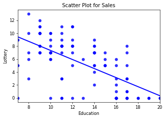

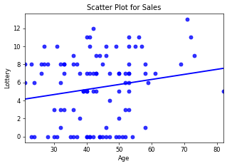

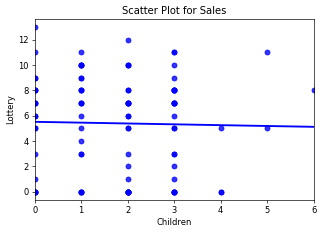

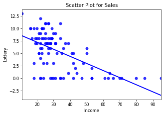

```python
y_var = df['Lottery'].values
xnames = ['Education', 'Age', 'Children', 'Income']
for aname in xnames:
    x_var = df[aname].values
    _ = sns.regplot(x = x_var, y = y_var, data = df, color = 'b', ci = None)
    plt.title('Scatter Plot for Sales')
    plt.xlabel(aname)
    plt.ylabel('Lottery')
    plt.show()
```

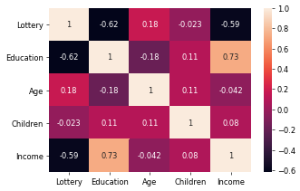

```python
corr = df.corr()
_ = sns.heatmap(corr, annot=True)
```

Lottery spend = $\beta 0 $ + $\beta 1 $ x1 + $\beta 2 $ x2 + $\beta 3 $ x3 + $\beta 4 $ x4 + $\epsilon$

```python
y = df['Lottery']

X_ar = np.array([df['Education'], df['Age'], df['Children'], df['Income']])
X_T =X_ar.T
X = pd.DataFrame(X_T,columns = xnames)
X = sm.add_constant(X)

olsmod = sm.OLS(y, X)
result = olsmod.fit()
print(result.summary())
```

```
                            OLS Regression Results
==============================================================================
Dep. Variable:                Lottery   R-squared:                       0.433
Model:                            OLS   Adj. R-squared:                  0.410
Method:                 Least Squares   F-statistic:                     18.17
Date:                Mon, 31 May 2021   Prob (F-statistic):           4.09e-11
Time:                        01:31:52   Log-Likelihood:                -246.14
No. Observations:                 100   AIC:                             502.3
Df Residuals:                      95   BIC:                             515.3
Df Model:                           4
Covariance Type:            nonrobust
==============================================================================
                 coef    std err          t      P>|t|      [0.025      0.975]
------------------------------------------------------------------------------
const         11.9061      1.785      6.669      0.000       8.362      15.450
Education     -0.4300      0.132     -3.256      0.002      -0.692      -0.168
Age            0.0292      0.025      1.157      0.250      -0.021       0.079
Children       0.0934      0.224      0.417      0.678      -0.352       0.539
Income        -0.0745      0.028     -2.686      0.009      -0.130      -0.019
==============================================================================
Omnibus:                        8.994   Durbin-Watson:                   2.024
Prob(Omnibus):                  0.011   Jarque-Bera (JB):                8.988
Skew:                          -0.722   Prob(JB):                       0.0112
Kurtosis:                       3.265   Cond. No.                         353.
==============================================================================

Notes:
[1] Standard Errors assume that the covariance matrix of the errors is correctly specified.
```

```python
print("Estimated model: y = %0.4f" % (result.params[0]), end = ' ')
for c, x in zip(result.params[1:], list(range(1,5))):
    print('+', end = '') if c> 0 else print('-', end = '')
    print(" %0.4f x%d " % (abs(c), x), end = '')
```

```
Estimated model: y = 11.9061 - 0.4300 x1 + 0.0292 x2 + 0.0934 x3 - 0.0745 x4
```

#### (b)

H0 : $\beta i $ = 0 for i in [1,4]  
H1 : exists at least one $\beta i$ != 0 for i in [1,4]  
$\alpha$ = 0.05

```python
print("F-statistics:", result.fvalue)
print("p-value:",result.f_pvalue)
```

```
F-statistics: 18.172174947407566
p-value: 4.094433943487536e-11
```

Since p-value < alpha = 0.05, we reject H0 at significance level at alpha = 0.05.  
There is enough evidence to conclude that the model is valid.

```python
print('Standard errors:', result.mse_resid ** 0.5)
print('Y_bar:', df["Lottery"].mean())
```

```
Standard errors: 2.9097800223456094
Y_bar: 5.39
```

Compared to y_bar = 5.39, Se = 2.910 isnt relatively small. Hence our regression model of might not be good.

```python
print("R2:", result.rsquared)
print("adjusted R2:", result.rsquared_adj)
```

```
R2: 0.43347404971724446
adjusted R2: 0.40962032549481264
```

| R2 - adjusted R2 | < 0.06, which indicates model doesn't have problem of over-fitting.  
However, only 43.35% of the variation in Lottery is explained by the model, which indicates the model might not be good.

#### (c)

H0 : $\beta i$ = 0 for i in [1,4]  
H1 : $\beta i$ < 0 for belief 1 and 4; $\beta i$ > 0 for belief 2 and 3

$\alpha$ = 0.05

```python
for x, p in zip(xnames, result.pvalues[1:]):
    print("p-value of %s = %0.4f" % (x, p/2))
    if p < 0.05:
        print("  Since p-value < alpha = 0.05, we reject H0 at significance level at alpha = 0.05.")
    else:
        print("  Since p-value > alpha = 0.05, we can not reject H0 at significance level at alpha = 0.05.")
```

```
p-value of Education = 0.0008
  Since p-value < alpha = 0.05, we reject H0 at significance level at alpha = 0.05.
p-value of Age = 0.1251
  Since p-value > alpha = 0.05, we can not reject H0 at significance level at alpha = 0.05.
p-value of Children = 0.3390
  Since p-value > alpha = 0.05, we can not reject H0 at significance level at alpha = 0.05.
p-value of Income = 0.0043
  Since p-value < alpha = 0.05, we reject H0 at significance level at alpha = 0.05.
```

There is enough evidence to support beliefs 1 and 4:  
1.There is enough evidence to support that ralatively uneducated people spend more on lotteries then do relatively educated people.  
4.Relatively poor people spend a greater proportion of their income on lotteries than relatively rich people.

There is not enough evidence to support beliefs 2 and 3:  
2.Older people buy more lottery tickets than younger people.  
3.People with more children spend more on lotteries than people with few children.

### Residual analysis

```python
st, data, ss2 = sso.summary_table(result, alpha=0.05)
#Predicted value
y_pre = data[:, 2]
#Studentized Residual
SD = data[:, 10]
```

#### Normality

H0 : Normal distributed  
H1 : Not normal distributed

```python
stat, p = stats.shapiro(SD)
print('Shapiro Test: Statistics=%.3f, p=%.3f' % (stat, p))
```

```
Shapiro Test: Statistics=0.960, p=0.004
```

#### Homoscedasticity

H0 : Homoscedasticity  
H1 : Not Homoscedasticity

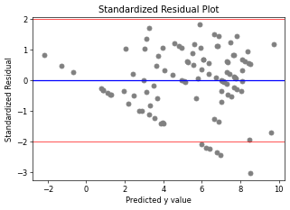

```python
plt.plot(y_pre, SD, 'o', color = 'gray')
plt.axhline(y=2, color = 'red', lw = 0.8)
plt.axhline(y=0, color = 'blue')
plt.axhline(y=-2, color = 'red', lw = 0.8)
plt.title('Standardized Residual Plot')
plt.xlabel('Predicted y value')
plt.ylabel('Standardized Residual')
plt.show()
```

From the plot above, it doesnt satisfy that the variation is constant and the mean is around 0. Thus, we reject H0. The residual doesnt satisfy the condition of homoscedasticity.  
(這題寫not reject H0 也給對)

#### Independence

H0 : Independence  
H1 : Not independence

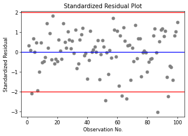

```
runs =  51
n1 =  50
n2 =  50
runs_exp =  51.0
stan_dev =  4.97468338163091
z =  0.0
pval_z =  1.0
p_value for Z-statistic=  1.0
```

```python
Id = data[:, 0]
plt.plot(Id, SD, 'o', color = 'gray')
plt.axhline(y=0, color = 'blue')
plt.axhline(y=2, color = 'red')
plt.axhline(y=-2, color = 'red')
plt.title('Standardized Residual Plot')
plt.xlabel('Observation No.')
plt.ylabel('Standardized Residual')
plt.show()

SD_median = statistics.median(SD)
Z_pval = runsTest(SD, SD_median)
print('p_value for Z-statistic= ', Z_pval)
```

Since n1>20 and n2>20, we can apply run test with normal distribution.  
Since p-value > alpha = 0.05, we can not reject H0 at significance level at alpha = 0.05.  
There is no evidence to infer the sample is not random selected.

```python
df_c = pd.DataFrame(SD,columns = ['SD'])
filter = (df_c['SD'] < -2) | (df_c['SD'] > 2)
print("Outliers by SD = \n")
print(df_c['SD'].loc[filter])
```

```
Outliers by SD =

2    -2.083013
51   -2.436117
62   -2.198966
65   -2.352427
86   -3.019747
93   -2.234923
Name: SD, dtype: float64
```

```python
X = np.array(X)
H = np.matmul(X, np.linalg.solve(np.matmul(X.T, X), X.T))
df['hii'] = np.diagonal(H)
df_h = pd.DataFrame(df['hii'])
k = result.df_model
n = len(df_h['hii'])
h_level = 3 * (k+1) / n
print("h_level = ", h_level)
print(" \n")
filter = (df_h['hii'] > h_level )
print("Influential Observations by hi = \n")
print(df_h['hii'].loc[filter])
```

```
h_level =  0.15


Influential Observations by hi =

60    0.156214
61    0.185862
Name: hii, dtype: float64
```

```python
s2_e = result.mse_resid
k = result.df_model
y_a = data[:, 1]
y_f = data[:, 2]
h_i = df['hii']
CD_arr = np.square(y_a - y_f) / s2_e / (k - 1) * h_i / np.square(1 - h_i)
CD = np.array(CD_arr)
df_cd = pd.DataFrame(CD,columns = ['CD'])
filter = (df_cd['CD'] > 1 )
print("Influential Observations by Cook's Distances = \n")
print(df_cd['CD'].loc[filter])
```

```
Influential Observations by Cook's Distances =

Series([], Name: CD, dtype: float64)
```